# Module 2, Lesson 1: Simple linear regression

Open a new R script. At the top of this script, load the `tidyverse` and the `healthds` package.

```r
library(healthds)
library(tidyverse)
```

As you read about just before the Guided Practice, the `healthds` package contains several synthetic datasets for purposes of practicing statistical methods. Please refer that reading for additional details.

(in the Guided Practice video, Dr. Boonstra mistakenly said that you first need to use the `data("BPUrban300")` command – that is not true.)

These data are stored as so-called data.frames and not tibbles, which is how most of the data we’ve encountered so far are stored. For tibbles, R will automatically trim the rows and columns that are printed, but for data.frame it will not. The practical implication is that if you try to print these data to the screen, it will be too much data for the screen. Instead, you can type `View(BPUrban300)` in your console to open up a spreadsheet-like interface in RStudio, or you can use the `head` function to view just the first few rows of the data:

```r
head(BPUrban300)
```

```
##   hypertension systolic diastolic  bmi  bmi_group cholesterol age age_group
## 1            0      156        82 30.4  BMI>27.49         171  60     45-59
## 2            0       89        75 31.3  BMI>27.49         216  57     45-59
## 3            0      132        62 28.0  BMI>27.49         157  54     45-59
## 4            0       98        45 21.8 BMI<=27.49         117  75      >=60
## 5            0      101        76 28.4  BMI>27.49         205  71      >=60
## 6            0       57        78 35.0  BMI>27.49         200  33     30-44
##   parent_history_HTN salt  salt_group smoking chewing  activity weight
## 1               both  2.3     Salt<=5   FALSE    TRUE  moderate   77.0
## 2               none  5.8  5<Salt<=10   FALSE    TRUE      mild   75.8
## 3               none  8.7  5<Salt<=10   FALSE    TRUE sedentary   68.3
## 4               none  4.7     Salt<=5   FALSE   FALSE sedentary   55.1
## 5               none 19.8 10<Salt<=20   FALSE   FALSE      mild   80.5
## 6               none 19.9 10<Salt<=20    TRUE   FALSE  moderate   77.3
##   waist_circumference hip_circumference waist_hip_ratio fasting_glucose
## 1                98.0              95.6            1.02             172
## 2                75.6              75.7            1.00              53
## 3                72.0              77.3            0.93              86
## 4                67.2              60.6            1.11              53
## 5                69.1              87.6            0.79             117
## 6                85.5              90.0            0.95             124
##            caste marital_status religion  education gender
## 1 Schedule tribe        Married    Hindu >=Graduate Female
## 2    Other caste        Married     Sikh  <=Primary   Male
## 3        General        Married    Hindu >=Graduate Female
## 4        General        Married    Hindu       High   Male
## 5 Schedule caste        Married    Hindu     Middle   Male
## 6        General        Married    Hindu       High   Male
```

Let’s first inspect some of the variables in these data. A histogram of systolic blood pressure (`systolic`) in these data can be constructed as such:

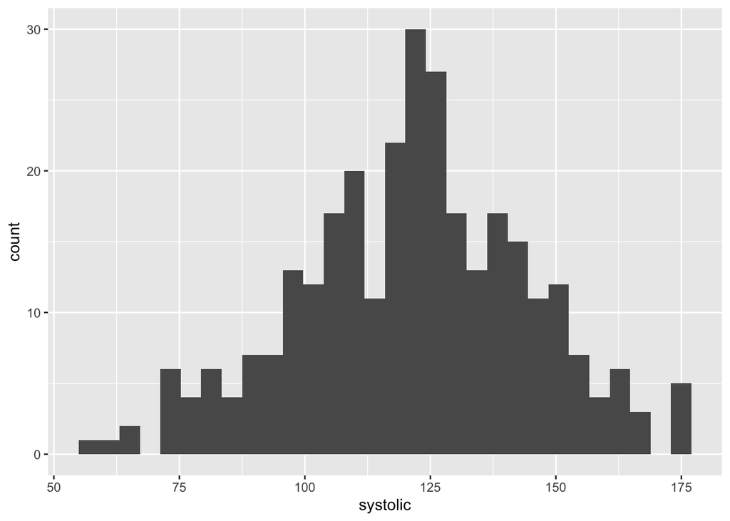

```r
ggplot(BPUrban300) +
  geom_histogram(aes(systolic), bins = 30)
```

We can also inspect the relationship between systolic blood pressure and the age of the person:

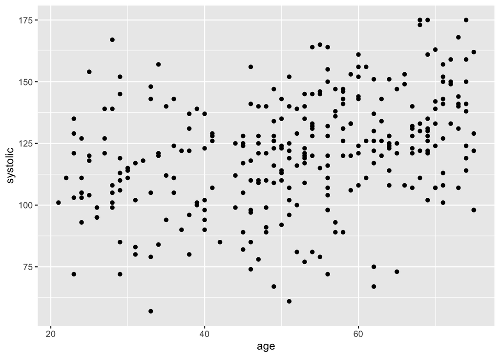

```r
ggplot(BPUrban300) +
  geom_point(aes(age, systolic))
```

## Linear models in R

We will now fit a linear regression model, regressing `systolic` against `age` to estimate the extent to which typical values systolic blood pressure change with a person’s age in these data. We will use the `lm` function in R to do so.

The regression equation is specified via the `formula` argument in `lm`. A formula starts with the name of a variable that is intended to be the outcome. Next comes a tilde (`~`) symbol. Finally, it ends with the name of a variable that is intended to be the covariate / predictor. So, our formula will be `systolic ~ age`. We also need to point `lm` to the dataset in which to “look” for these variables – in our case that is `BPUrban300`. Putting this together, we can fit our regression model with the following:

```r
lm(formula = systolic ~ age, data = BPUrban300)
```

```
##
## Call:
## lm(formula = systolic ~ age, data = BPUrban300)
##
## Coefficients:
## (Intercept)          age
##     93.8760       0.5371
```

The output gives us just two things: the Call, which just gives back the code that we gave it, and the Coefficients, which gives the intercept parameter ($\beta_0$ from Dr. Mukherjee’s slides) and the slope parameter corresponding to age ($\beta_1$). Importantly, this tells us that the expected systolic blood pressure increases by about 0.5 points between any two people in our data who are 1 year apart in age.

Congratulations on fitting your first linear regression. There is much more to be done and learned with regard to regression. In future lessons, we will learn more about how to conduct estimation and prediction.